# Single- and multi-trait association analysis on body-related traits in UKBiobank

Andrey Ziyatdinov

2018-05-11

# 1 About

Project code repository: https://github.com/hemostat/ukbjass.

Shared single-trait summary stats and LDSC results at `o2.hms.harvard.edu`:

```
ls /home/az99//income/ukbjass/
body_BMIz_orth.annot.sumstats.gz     body_WEIGHT_orth.annot.sumstats.gz
body_HEIGHTz_orth.annot.sumstats.gz  body_WHR_orth.annot.sumstats.gz
body_HIP_orth.annot.sumstats.gz      h2.ldsc.rds
body_WAIST_orth.annot.sumstats.gz    rho.ldsc.rdata
```

# 2 Summary

| Variable | Value | Comment |
| --- | --- | --- |
| #individuals | 336,347/337,536 | unrelated; British ancestry; NAs for any trait is removed (1,189) |
| #SNPs | 619,017 | genotyped; clean; MAF > 1% |
| #traits | 5 | 5 anthropometric traits (height is removed; see below) |

# 3 Protocol

Traits:

- project out covariates form traits (see below);
- remove individuals, for whom any trait value is missing (so, there is complete overlap in terms of phenotyping).

SNPs:

- take genotyped SNPs;
- use QC following the Po-Ru’s pipeline;
- filter out SNPs with MAF <1%.

Estimation of phenotypic correlations using [LDSC](https://github.com/bulik/ldsc):

- compute LD-scores for our SNPs using 1,000 Genomes reference panel of `EUR`;
  - unexpectedly, there are only approx. 100,000/600,000 HapMap 3 SNPs in our sample;
- run bi-variate LDSC to estimate $\rho$ parameter;
- run uni-variate LDSC to asses the population stratification.

GWAS:

- run [PLINK 1.9](https://www.cog-genomics.org/plink/1.9/) for single-trait GWAS
- run [plink.multivariate](https://genepi.qimr.edu.au/staff/manuelF/multivariate/main.html) for CCA-based multi-trait GWAS;
- run cusom R code (see below) for JASS.

## 3.1 Inflation of single-trait GWAS statistic

| trait | lambda |
| --- | --- |
| body_BMIz_orth | 1.62 |
| body_HEIGHTz_orth | 1.89 |
| body_HIP_orth | 1.56 |
| body_WAIST_orth | 1.53 |
| body_WEIGHT_orth | 1.65 |
| body_WHR_orth | 1.46 |

## 3.2 Phenotypic correlation coefficient

Plots:

- phenotypic correlations estimated on raw data of phenotypes;
- phenotypic correlations ($\rho = \rho_g + \rho_e$) estimated on summary stats by LDSC;
- absolute (signed) errors;
- relative (signed) errors.

By looking at the last plot, we’ve decided to exclude Height from the multi-trait analysis.

Also, there is a systematic upward bias in estimation of $\rho$ by LDSC.

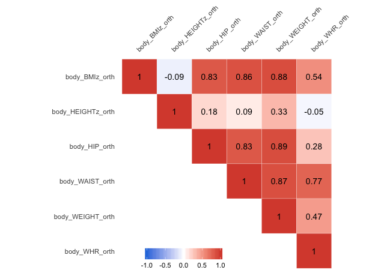

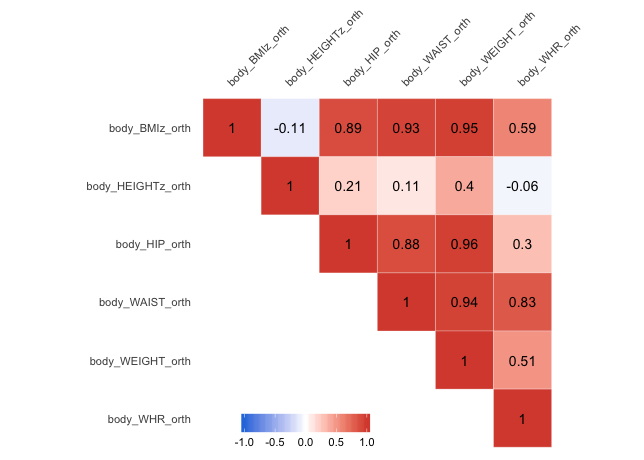

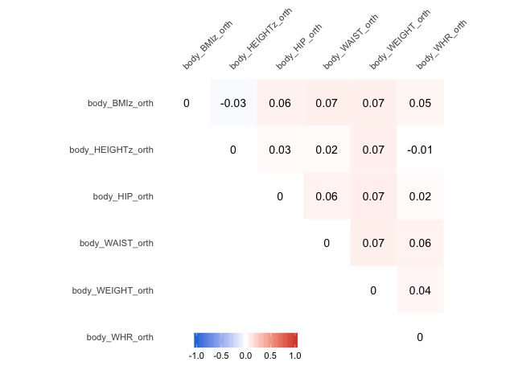

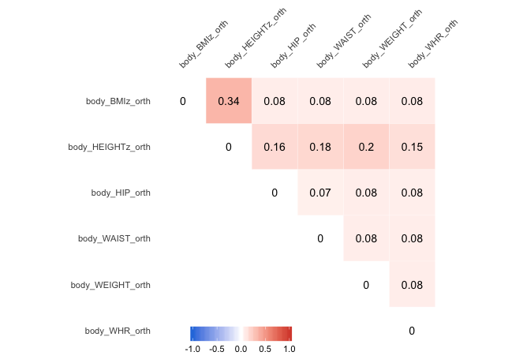

### 3.2.1 LDSC stats on h2

| trait | Total Observed scale h2 | Lambda GC | Mean Chi^2 | Intercept | Ratio |
| --- | --- | --- | --- | --- | --- |
| body_BMIz_orth | 0.2313 (0.0091) | 1.6145 | 1.9898 | 1.1095 (0.0107) | 0.1106 (0.0108) |
| body_HEIGHTz_orth | 0.4881 (0.0235) | 1.8809 | 3.4525 | 1.2858 (0.0214) | 0.1165 (0.0087) |
| body_HIP_orth | 0.2111 (0.0099) | 1.5585 | 1.9597 | 1.0888 (0.0104) | 0.0926 (0.0109) |
| body_WAIST_orth | 0.1926 (0.0076) | 1.529 | 1.8027 | 1.0899 (0.0097) | 0.112 (0.0121) |
| body_WEIGHT_orth | 0.2532 (0.0109) | 1.6448 | 2.1665 | 1.1204 (0.0118) | 0.1032 (0.0101) |
| body_WHR_orth | 0.1554 (0.0062) | 1.453 | 1.7059 | 1.0884 (0.0095) | 0.1252 (0.0134) |

https://github.com/bulik/ldsc/wiki/Heritability-and-Genetic-Correlation:

> Lambda GC is median(chi^2)/0.4549. Mean chi^2 is the mean chi-square statistic. Intercept is the LD Score regression intercept. The intercept should be close to 1, unless the data have been GC corrected, in which case it will often be lower. Ratio is (intercept-1)/(mean(chi^2)-1), which measures the proportion of the inflation in the mean chi^2 that the LD Score regression intercept ascribes to causes other than polygenic heritability. The value of ratio should be close to zero, though in practice values of 10-20% are not uncommon, probably due to sample/reference LD Score mismatch or model misspecification (e.g., low LD variants have slightly higher h^2 per SNP)

### 3.2.2 A special case of GWAS on Height

https://www.cell.com/cms/attachment/2107562562/2082039991/mmc1.pdf?code=cell-site (page 6):

> But in the case of height there are two key issues: (1) essentially all of the genome is associated with height, and (2) selection on height has likely played a causal role in driving allele frequency differentiation across Europe. Thus if we correct for structure aggressively we are actually likely to remove real signal. We suspect that current methods may over-correct for structure for other highly polygenic traits as well, although the bias should be less severe in most other cases

## 3.3 Comparison between PLINK-CCA and JASS (preliminary results on Chr. 20)

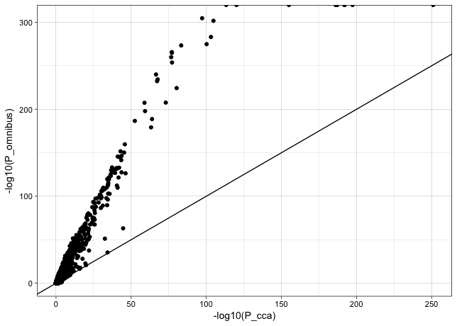

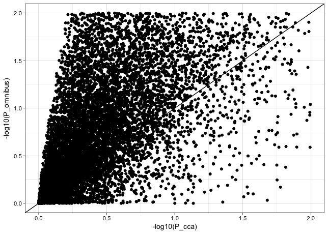

### 3.3.1 Look at particular SNPs

SNPs with `-log10(P_cca) > 100`:

| SNP | P_omnibus | P_cca |
| --- | --- | --- |
| rs6038557 | 2.04e-302 | 1.63e-105 |
| rs2145270 | 1.42e-275 | 5.51e-101 |
| rs2145272 | 8.01e-284 | 7.29e-104 |
| rs2425052 | 0.00e+00 | 4.84e-114 |
| rs6060369 | 0.00e+00 | 8.09e-187 |
| rs6088792 | 0.00e+00 | 7.73e-121 |
| rs6060373 | 0.00e+00 | 6.55e-188 |
| rs4911494 | 0.00e+00 | 1.15e-192 |
| rs4911179 | 0.00e+00 | 8.16e-193 |
| rs6088813 | 0.00e+00 | 8.14e-193 |
| rs224331 | 0.00e+00 | 9.48e-156 |
| rs143384 | 0.00e+00 | 8.68e-252 |
| rs78110303 | 0.00e+00 | 3.76e-198 |

#### 3.3.1.1 SNP rs6038557

Z-scores from single-trait GWAS:

| body_BMIz_orth | body_HIP_orth | body_WAIST_orth | body_WEIGHT_orth | body_WHR_orth |
| --- | --- | --- | --- | --- |
| -8.39 | -4.05 | -1.11 | 0.741 | 2.94 |

P-values from single-trait GWAS:

| body_BMIz_orth | body_HIP_orth | body_WAIST_orth | body_WEIGHT_orth | body_WHR_orth |
| --- | --- | --- | --- | --- |
| 4.86e-17 | 5.12e-05 | 0.265 | 0.459 | 0.00323 |

Results from PLINK-CAA on multi-trait analysis:

| CHR | SNP | BP | NFAM | NIND | F | P | WEIGHTS |
| --- | --- | --- | --- | --- | --- | --- | --- |
| 20 | rs6038557 | 6,594,349 | 329,613 | 329,613 | 99.8 | 1.63e-105 | -0.3759,-0.1814,-0.0499,0.03321,0.1319 |

# 4 Appendix

## 4.1 Linear models for single-trait GWAS

Traits:

```
[1] "body_BMIz"    "body_HEIGHTz" "body_HIP"     "body_WAIST"
[5] "body_WEIGHT"  "body_WHR"
```

Covariates which were projected out:

```
 [1] "cov_ASSESS_CENTER" "cov_GENO_ARRAY"    "cov_SEX"
 [4] "cov_AGE"           "cov_AGE_SQ"        "PC1"
 [7] "PC2"               "PC3"               "PC4"
[10] "PC5"               "PC6"               "PC7"
[13] "PC8"               "PC9"               "PC10"
[16] "PC11"              "PC12"              "PC13"
[19] "PC14"              "PC15"              "PC16"
[22] "PC17"              "PC18"              "PC19"
[25] "PC20"              "PC21"              "PC22"
[28] "PC23"              "PC24"              "PC25"
[31] "PC26"              "PC27"              "PC28"
[34] "PC29"              "PC30"              "PC31"
[37] "PC32"              "PC33"              "PC34"
[40] "PC35"              "PC36"              "PC37"
[43] "PC38"              "PC39"              "PC40"
```

New names of covariate-free traits (use in our analysis of GWAS, JASS and PLINK-CCA):

```
[1] "body_BMIz_orth"    "body_HEIGHTz_orth" "body_HIP_orth"
[4] "body_WAIST_orth"   "body_WEIGHT_orth"  "body_WHR_orth"
```

## 4.2 R code to compute JASS (Omnibus)

Input:

- a matrix Z of single-trait Z-scores with SNPs in rows and Z-scores in columns;
- a covariance matrix among Z-scores (in practice, estimated by LDSC as phenotypic correlations)

```r
ukbjass_omnibus <- function(Z, Sigma)
{
  ### check
  stopifnot(all(colnames(Z) == rownames(Sigma)))
  stopifnot(all(colnames(Z) == colnames(Sigma)))

  ### Omnibus test
  Sigma_inv <- solve(Sigma)

  P1 <- tcrossprod(Z, Sigma_inv)
  P2 <- P1 * Z # element-wise multiplication
  Z2 <- rowSums(P2)

  pval <- pchisq(Z2, df = ncol(Z), lower = FALSE)
}
```

## 4.3 Plink-CCA log

```
@----------------------------------------------------------@
|        PLINK!       |     v1.06p     |   26/Feb/2009     |
|----------------------------------------------------------|
|  (C) 2009 Shaun Purcell, GNU General Public License, v2  |
|----------------------------------------------------------|
|  For documentation, citation & bug-report instructions:  |
|        http://pngu.mgh.harvard.edu/purcell/plink/        |
@----------------------------------------------------------@

Skipping web check... [ --noweb ]
Writing this text to log file [ plink.log ]
Analysis started: Thu May 10 15:55:43 2018

Options in effect:
    --noweb
    --allow-no-sex
    --bfile /home/az99/Data/UKBiobank/jass/clean.maf_0.01//20.clean
    --mult-pheno /home/az99/Data/UKBiobank/jass/phen//ukb.jass.plink.pdat
    --pheno-name body_BMIz_orth,body_HIP_orth,body_WAIST_orth,body_WEIGHT_orth,body_WHR_orth
    --mqfam

Reading map (extended format) from [ /home/az99/Data/UKBiobank/jass/clean.maf_0.01//20.clean.bim ]
16226 markers to be included from [ /home/az99/Data/UKBiobank/jass/clean.maf_0.01//20.clean.bim ]
Reading pedigree information from [ /home/az99/Data/UKBiobank/jass/clean.maf_0.01//20.clean.fam ]
337539 individuals read from [ /home/az99/Data/UKBiobank/jass/clean.maf_0.01//20.clean.fam ]
0 individuals with nonmissing phenotypes
Assuming a disease phenotype (1=unaff, 2=aff, 0=miss)
Missing phenotype value is also -9
0 cases, 0 controls and 337539 missing
156268 males, 181268 females, and 3 of unspecified sex
Warning, found 3 individuals with ambiguous sex codes
Writing list of these individuals to [ plink.nosex ]
Reading genotype bitfile from [ /home/az99/Data/UKBiobank/jass/clean.maf_0.01//20.clean.bed ]
Detected that binary PED file is v1.00 SNP-major mode
Reading 6 phenotypes from [ /home/az99/Data/UKBiobank/jass/phen//ukb.jass.plink.pdat ] with nonmissing values for 336347 individuals
Selected subset of 5 from 6 phenotypes
For these, nonmissing phenotype values for 337536 individuals
Before frequency and genotyping pruning, there are 16226 SNPs
337539 founders and 0 non-founders found
Total genotyping rate in remaining individuals is 0.994875
0 SNPs failed missingness test ( GENO > 1 )
0 SNPs failed frequency test ( MAF < 0 )
After frequency and genotyping pruning, there are 16226 SNPs
After filtering, 0 cases, 0 controls and 1192 missing
After filtering, 156268 males, 181268 females, and 3 of unspecified sex
337539 nuclear families, 337539 founder singletons found
0 non-founders with 2 parents in 0 nuclear families
0 non-founders without 2 parents in 0 nuclear families
0 affected offspring trios
0 phenotypically discordant parent pairs found
Converting data to Individual-major format
0 Mendel errors detected in total
Converting data to SNP-major format
Writing MQFAM asymptotic results to [ plink.mqfam.total ]
** Warning ** MQFAM results require permutation to correct for family structure
337539 nuclear families in analysis
```